# Ecología Aplicada - Datos de Biodiversidad

Docente: Anggelo Tena

Alumno: Diego Morante, 2024-03-29

## Datos

Los datos utilizados se descargaron de [GBIF](https://www.gbif.org/es/occurrence/search), una red internacional e infraestructura de datos de acceso abierto que ofrece información de biodiversidad de las formas de vida en la tierra.

- Acceder con una cuenta de usuario.
- Ir a Datos y dar clic a Registro de presencia.
- En el buscardor, porner el nombre científico de la especie, en este caso el Cormorán Guanay *Phalacrocorax bougainvillii*.
- Agregamos un filtro, en este caso **Perú** .
- En el Visor del Registro de Presencia, le damos a **descargar**.
- Por último, le damos al botón *.csv*

[figure not shown]

Cormorán

## Lectura de Datos CSV

Se hace la lectura del archivo **.csv** con **read.csv()**, el cual contiene argumentos de la ruta del archivo y el tabulador como separador de las columnas representado por `"\t"`.

```r
cormoran <- read.csv("C:/Users/diego/Documents/ecologia guias/cormoran/databruto.csv", sep="\t")
```

## Visualización de los Datos CSV

Permite visualizar los datos en una tabla en Rstudio.

```r
view(cormoran)
```

|  | stateProvince | decimalLatitude | decimalLongitude | day | month | year |
| --- | --- | --- | --- | --- | --- | --- |
| 1 | Ica | -13.8355 | -76.25001 | 9 | 11 | 1968 |
| 2 | Ica | -13.8355 | -76.25001 | 9 | 11 | 1968 |
| 3 | Ica | -13.8355 | -76.25001 | 9 | 11 | 1968 |
| 4 | Ica | -13.8355 | -76.25001 | 9 | 11 | 1968 |
| 5 | Ica | -13.8355 | -76.25001 | 9 | 11 | 1968 |
| 6 | Ica | -13.8355 | -76.25001 | 9 | 11 | 1968 |
| 7 | Ica | -13.8355 | -76.25001 | 9 | 11 | 1968 |
| 8 | Ica | -13.8355 | -76.25001 | 9 | 11 | 1968 |
| 9 | Ica | -13.8355 | -76.25001 | 6 | 11 | 1968 |
| 10 |  | -13.83999 | -76.25207 |  |  |  |

[output cut: 105 more lines]

Muestra las dimensiones de los datos en números de filas y columnas.

```r
dim(cormoran)
```

```
## [1] 115  50
```

**sort()** Permite mostrar de manera ordenada los nombres de los campos de los datos **names()**.

```r
sort(names(cormoran))
```

```
##  [1] "basisOfRecord"                    "catalogNumber"
##  [3] "class"                            "collectionCode"
##  [5] "coordinatePrecision"              "coordinateUncertaintyInMeters"
##  [7] "countryCode"                      "datasetKey"
##  [9] "dateIdentified"                   "day"
## [11] "decimalLatitude"                  "decimalLongitude"
## [13] "depth"                            "depthAccuracy"
## [15] "elevation"                        "elevationAccuracy"
## [17] "establishmentMeans"               "eventDate"
## [19] "family"                           "gbifID"
## [21] "genus"                            "identifiedBy"
## [23] "individualCount"                  "infraspecificEpithet"
## [25] "institutionCode"                  "issue"
## [27] "kingdom"                          "lastInterpreted"
## [29] "license"                          "locality"
## [31] "mediaType"                        "month"
## [33] "occurrenceID"                     "occurrenceStatus"
## [35] "order"                            "phylum"
## [37] "publishingOrgKey"                 "recordedBy"
## [39] "recordNumber"                     "rightsHolder"
## [41] "scientificName"                   "species"
## [43] "speciesKey"                       "stateProvince"
## [45] "taxonKey"                         "taxonRank"
## [47] "typeStatus"                       "verbatimScientificName"
## [49] "verbatimScientificNameAuthorship" "year"
```

**Unique()** Muestra los datos sin repetir los elementos de una columna específica **data$columna**

```r
unique(cormoran$countryCode)
```

```
## [1] "PE"
```

```r
unique(cormoran$decimalLatitude)
```

```
##  [1] -13.835500 -13.839990         NA  -9.580000 -13.630000  -8.550000
##  [7] -13.650000 -15.350000  -6.852194 -11.416700 -17.015319 -17.014094
## [13]  -4.700000 -15.671667  -5.079419 -12.478053  -4.590285
```

```r
unique(cormoran$decimalLongitude)
```

```
##  [1] -76.25001 -76.25207        NA -78.26000 -76.42000 -78.95000 -76.40000
##  [8] -75.17000 -79.91920 -77.71670 -72.11169 -72.11200 -80.50000 -74.53667
## [15] -80.01624 -76.77037 -81.27823
```

```r
unique(cormoran$locality)
```

```
##  [1] "Paracas"
##  [2] "Paracas, Paracas Bay"
##  [3] "Lobos de Tierra"
##  [4] "N. Chincha I."
##  [5] "Mollendo Harbor"
##  [6] "Pescadores Is."
##  [7] "Lobos de Tierra I."
##  [8] "Lobos de Tierra Is."
##  [9] "Labos de Tierra"
## [10] "Ancon"
## [11] "ISLAS DE CHINCHA"
## [12] "ISLA LOBOS DE TIERRA"
## [13] "ISLA MAZORCA"
## [14] "OFF SHORE"
## [15] "Lima,"
```

[output cut: 22 more lines]

**Filter()** Es una función de la *librería Tydiverse*, que ayuda a filtrar los datos guardandolas en una variable.

```r
library(tidyverse)
cormoran_filtrado <- filter(cormoran, cormoran$countryCode == "PE")
dim(cormoran_filtrado)
```

```
## [1] 115  50
```

**subset()** es una función que recorta los datos en función de una selección. En este ejemplo, la selección se realiza en los datos vacíos o NA utilizando **is.na()**, el cual se invierte al agregarle **!** en la izquierda, seleccionando finalmente los datos no vacíos.

Con esto, conseguimos una limpieza de los datos, con respecto al campo de coordenadas **decimalLongitude**, el cual se verifica con la variación del número de filas de la data con la función **dim()**.

```r
cormoran_cortado <- subset(cormoran_filtrado, !is.na(decimalLongitude))
dim(cormoran_cortado)
```

```
## [1] 45 50
```

|  | stateProvince | decimalLatitude | decimalLongitude | day | month | year |
| --- | --- | --- | --- | --- | --- | --- |
| 1 | Ica | -13.8355 | -76.25001 | 9 | 11 | 1968 |
| 2 | Ica | -13.8355 | -76.25001 | 9 | 11 | 1968 |
| 3 | Ica | -13.8355 | -76.25001 | 9 | 11 | 1968 |
| 4 | Ica | -13.8355 | -76.25001 | 9 | 11 | 1968 |
| 5 | Ica | -13.8355 | -76.25001 | 9 | 11 | 1968 |
| 6 | Ica | -13.8355 | -76.25001 | 9 | 11 | 1968 |
| 7 | Ica | -13.8355 | -76.25001 | 9 | 11 | 1968 |
| 8 | Ica | -13.8355 | -76.25001 | 9 | 11 | 1968 |
| 9 | Ica | -13.8355 | -76.25001 | 6 | 11 | 1968 |
| 10 |  | -13.83999 | -76.25207 |  |  |  |

[output cut: 35 more lines]

Por último, exportamos los datos por medio de la función **write.csv()** especificando la variable que contiene los datos y la ruta de guardado.

```r
write.csv(cormoran_cortado,"C:/Users/diego/Documents/ecologia guias/cormoran/datafiltrada.csv")
```

## Gráfica de los puntos

El siguiente código permite graficar los puntos de distribución del Cormorán de Guanay o Pato de Mar (*Phalacrocorax bougainvillii*) en el Perú.

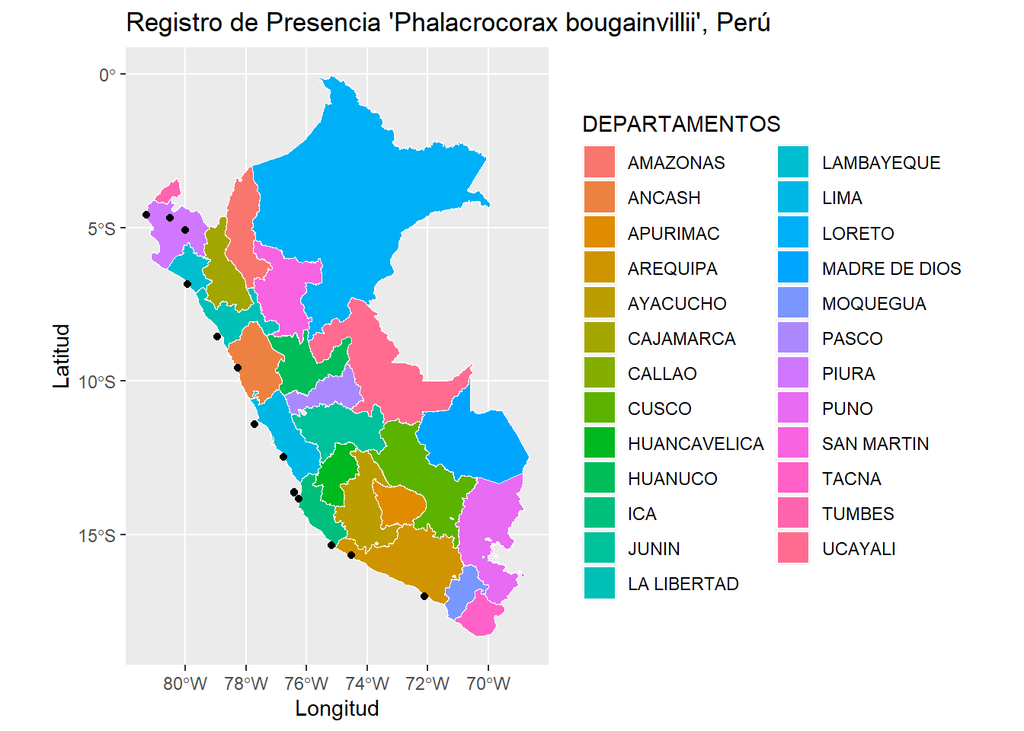

[interactive chart not shown]

```r
departamento <- read_sf("C:/Users/diego/Documents/ecologia guias/shapefiles de departamentos/DEPARTAMENTOS.shp")
ggplot() +
  geom_sf(data = departamento, color = "white", aes(fill= DEPARTAMEN))+
  labs(fill = "DEPARTAMENTOS") +
  geom_point(data = cormoran_cortado, aes(x = cormoran_cortado$decimalLongitude, y = cormoran_cortado$decimalLatitude), color="black") +
  labs(x="Longitud", y="Latitud", title="Registro de Presencia 'Phalacrocorax bougainvillii', Perú")
```